# R-Ladies St. Louis: Introduction to R

Xiaoyan Wang Public Health Sciences Program of Brown School Washington University in St. Louis

March 6, 2019

## Learning objectives

- What is R?
- Why R?
- Working with R objects
- Examples of data management
- Examples of data visualization

## What is R?

- R is a programming language and free software environment for statistical computing and graphics.
- R is an implementation of the S programming language that was created by John Chambers in 1976 at Bell Labs.
- R was later created by Ross Ihaka and Robert Gentlemn at the University of Auckland in 1992.
- One crucial feature of R: *packages* or *libraries*.
- Packages are collections of R functions, data, and compiled code in a well-defined format.
- R and its packages implement a wide variety of statistical and graphical techniques.

## Why R?

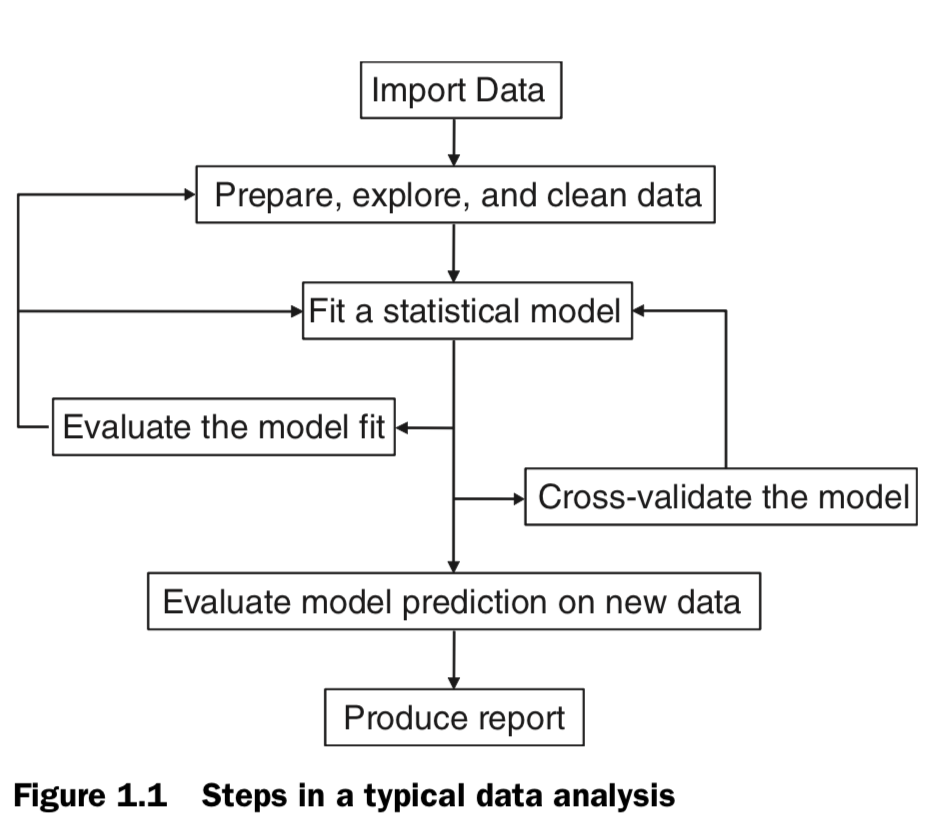

The steps in a typical data analysis

## Why R?

- Free
- Multi-platform
- Compatible with multiple data sources
- Interactive data analysis and exploration
- State-of-the-art graphics capabilities
- Open source and contains advanced statistical routines not yet available in other programs

## Working with R

- Case-sensitive and interpreted language
- Built-in and user-defined functions to create and manipulate objects (e.g., vectors, matrices, data frames, and lists)
- *<-* is the symbol for assignment
- *Comments* are preceded by the *#* sign

## Getting help and learning more

- ?topic or help(topic)
- If you get stuck, start with Google.
- If Google doesn’t help, try [stackoverflow](https://stackoverflow.com/).

## RStudio

- RStudio is a free and open-source integrated development environment for R
- You must install R before you can install RStudio
- Users can clearly view graphs, data tables, R code, and output all at the same time
- Packages for literate statistical programming - weaving written reports and analysis code in one document

## Working directory

- The directory in which you are currently working

```r
# Get the current working directory
getwd()
```

```
## [1] "/Users/candice_wang/Box/Conference_poster/RLadies"
```

```r
# To change the working directory, use setwd() with the directory path in
# quotes
setwd("/Users/candice_wang/desktop")  #use backslash or double forward slashes
```

## Packages

- Packages are collections of R functions, data, and compiled code in a well-defined format
- For packages you must install them THE FIRST TIME YOU USE THEM
- *NO NEED* to install every time
- Load each time you need them

```r
# install.packages('tidyverse') #Quotes are required
# install.packages(c('haven', labelled', 'ggpubr')) #easy way to install
# multiple packages

library(tidyverse)  # for ggplot2,tibble,tidyr,readr,purrr,dplyr,stringr,forcats
library(haven)  # for reading Stata, SPSS, SAS files
library(labelled)  # for working with variable labels
library(ggpubr)  #for customizing 'ggplot2'- based publication ready plots.
```

## Calculations

```r
# basic calculations
2 + 2
```

```
## [1] 4
```

```r
4 - 5
```

```
## [1] -1
```

```r
130 * 65
```

```
## [1] 8450
```

```r
144/6
```

```
## [1] 24
```

```r
(132 + 7) * 8 - 5
```

```
## [1] 1107
```

```r
# mathematical operations functions
sqrt(1024)
```

```
## [1] 32
```

```r
# powers and logs
32^2
```

```
## [1] 1024
```

```r
64^(1/2)
```

```
## [1] 8
```

```r
log(100)
```

```
## [1] 4.60517
```

```r
exp(4)
```

```
## [1] 54.59815
```

```r
# wrapping functions
log(exp(4))
```

```
## [1] 4
```

## Vectorization

```r
# use concatenate 'c()' to create a vector
c(4, 5, 6, 7, 8)
```

```
## [1] 4 5 6 7 8
```

```r
# use sequence 'seq()' to create a sequence
seq(from = 2, to = 100, by = 2)
```

```
##  [1]   2   4   6   8  10  12  14  16  18  20  22  24  26  28  30  32  34
## [18]  36  38  40  42  44  46  48  50  52  54  56  58  60  62  64  66  68
## [35]  70  72  74  76  78  80  82  84  86  88  90  92  94  96  98 100
```

```r
seq(100, 2, -2)  #sequence in a descending order
```

```
##  [1] 100  98  96  94  92  90  88  86  84  82  80  78  76  74  72  70  68
## [18]  66  64  62  60  58  56  54  52  50  48  46  44  42  40  38  36  34
## [35]  32  30  28  26  24  22  20  18  16  14  12  10   8   6   4   2
```

```r
seq(2, 100, length.out = 50)  #sequence with 50 elements
```

```
##  [1]   2   4   6   8  10  12  14  16  18  20  22  24  26  28  30  32  34
## [18]  36  38  40  42  44  46  48  50  52  54  56  58  60  62  64  66  68
## [35]  70  72  74  76  78  80  82  84  86  88  90  92  94  96  98 100
```

```r
seq(2, 100, 2)/2
```

```
##  [1]  1  2  3  4  5  6  7  8  9 10 11 12 13 14 15 16 17 18 19 20 21 22 23
## [24] 24 25 26 27 28 29 30 31 32 33 34 35 36 37 38 39 40 41 42 43 44 45 46
## [47] 47 48 49 50
```

```r
round(seq(2, 100, 2)/seq(1, 10), 1)
```

```
##  [1]  2.0  2.0  2.0  2.0  2.0  2.0  2.0  2.0  2.0  2.0 22.0 12.0  8.7  7.0
## [15]  6.0  5.3  4.9  4.5  4.2  4.0 42.0 22.0 15.3 12.0 10.0  8.7  7.7  7.0
## [29]  6.4  6.0 62.0 32.0 22.0 17.0 14.0 12.0 10.6  9.5  8.7  8.0 82.0 42.0
## [43] 28.7 22.0 18.0 15.3 13.4 12.0 10.9 10.0
```

```r
# use rep to repeat first argument N times, where N = second arg
rep(5, 3)
```

```
## [1] 5 5 5
```

```r
rep(c(1, 2, 3), 10)
```

```
##  [1] 1 2 3 1 2 3 1 2 3 1 2 3 1 2 3 1 2 3 1 2 3 1 2 3 1 2 3 1 2 3
```

```r
# sort simple vectors from lowest to highest values
sort(rep(c(1, 2, 3), 10))
```

```
##  [1] 1 1 1 1 1 1 1 1 1 1 2 2 2 2 2 2 2 2 2 2 3 3 3 3 3 3 3 3 3 3
```

## Assigning values to variables

- The shortcut key for <- is Alt - for Windows, and option - for Mac

```r
# assign a vector to x
x <- c(20, 13, 5, 17, 9, 10, 14)
x
```

```
## [1] 20 13  5 17  9 10 14
```

```r
# str = structure (view object class, dimensions, contents)
str(x)
```

```
##  num [1:7] 20 13 5 17 9 10 14
```

```r
# assign the results to y
y <- sort(x, decreasing = FALSE)
y
```

```
## [1]  5  9 10 13 14 17 20
```

## Data types and objects

### Data types

- Numeric
- Integer
- Logical
- Character (or String)
- Factor

### Objects

- Vectors
- Matrices
- Lists
- Data frame

```r
# vectors - numeric
x <- 1:10
str(x)
```

```
##  int [1:10] 1 2 3 4 5 6 7 8 9 10
```

```r
# vectors - logical

x <- c(T, F, F, T)
str(x)
```

```
##  logi [1:4] TRUE FALSE FALSE TRUE
```

```r
# vectors - string/character
mycolors <- c("red", "blue", "green")
mycolors
```

```
## [1] "red"   "blue"  "green"
```

```r
str(mycolors)
```

```
##  chr [1:3] "red" "blue" "green"
```

```r
# vectors - factor (like a variable with value labels)
mycol2 <- factor(mycolors)
mycol2
```

```
## [1] red   blue  green
## Levels: blue green red
```

```r
levels(mycol2)
```

```
## [1] "blue"  "green" "red"
```

```r
str(mycol2)
```

```
##  Factor w/ 3 levels "blue","green",..: 3 1 2
```

```r
mycol3 <- factor(mycolors, levels = c("red", "blue", "green"))

# matrices
x <- matrix(c(2, 1, 2, 1, 2, 1, 1, 1, 1, 2, 2, 1))
x
```

```
##       [,1]
##  [1,]    2
##  [2,]    1
##  [3,]    2
##  [4,]    1
##  [5,]    2
##  [6,]    1
##  [7,]    1
##  [8,]    1
##  [9,]    1
## [10,]    2
## [11,]    2
## [12,]    1
```

```r
str(x)
```

```
##  num [1:12, 1] 2 1 2 1 2 1 1 1 1 2 ...
```

```r
x <- matrix(1:12, nrow = 2, byrow = T, ncol = 3)
x
```

```
##      [,1] [,2] [,3]
## [1,]    1    2    3
## [2,]    4    5    6
```

```r
# tibbles (like a dataset or data.frame)
x <- tibble(shape = c("square", "circle", "triangle", "octagon"), size = c(1.2,
    5.4, 3, 2.4), count = c(10, 22, 53, 43))
x
```

```
## # A tibble: 4 x 3
##   shape     size count
##   <chr>    <dbl> <dbl>
## 1 square    1.20  10.0
## 2 circle    5.40  22.0
## 3 triangle  3.00  53.0
## 4 octagon   2.40  43.0
```

```r
str(x)
```

```
## Classes 'tbl_df', 'tbl' and 'data.frame':    4 obs. of  3 variables:
##  $ shape: chr  "square" "circle" "triangle" "octagon"
##  $ size : num  1.2 5.4 3 2.4
##  $ count: num  10 22 53 43
```

```r
# lists
x1 <- c("This", "is", "a", "string", "vector")
x1
```

```
## [1] "This"   "is"     "a"      "string" "vector"
```

```r
x2 <- 1:5
x2
```

```
## [1] 1 2 3 4 5
```

```r
cs1 <- table(1:10, rep(c(1, 3), 5))
cs1
```

```
##
##      1 3
##   1  1 0
##   2  0 1
##   3  1 0
##   4  0 1
##   5  1 0
##   6  0 1
##   7  1 0
##   8  0 1
##   9  1 0
##   10 0 1
```

```r
mytib <- tibble(x1, x2)
mytib
```

```
## # A tibble: 5 x 2
##   x1        x2
##   <chr>  <int>
## 1 This       1
## 2 is         2
## 3 a          3
## 4 string     4
## 5 vector     5
```

```r
mylist <- list(x, x2, cs1, mytib)
mylist
```

```
## [[1]]
## # A tibble: 4 x 3
##   shape     size count
##   <chr>    <dbl> <dbl>
## 1 square    1.20  10.0
## 2 circle    5.40  22.0
## 3 triangle  3.00  53.0
## 4 octagon   2.40  43.0
##
## [[2]]
## [1] 1 2 3 4 5
##
## [[3]]
##
##      1 3
##   1  1 0
##   2  0 1
##   3  1 0
##   4  0 1
##   5  1 0
##   6  0 1
##   7  1 0
##   8  0 1
##   9  1 0
##   10 0 1
##
## [[4]]
## # A tibble: 5 x 2
##   x1        x2
##   <chr>  <int>
## 1 This       1
## 2 is         2
## 3 a          3
## 4 string     4
## 5 vector     5
```

```r
str(mylist)
```

```
## List of 4
##  $ :Classes 'tbl_df', 'tbl' and 'data.frame':    4 obs. of  3 variables:
##   ..$ shape: chr [1:4] "square" "circle" "triangle" "octagon"
##   ..$ size : num [1:4] 1.2 5.4 3 2.4
##   ..$ count: num [1:4] 10 22 53 43
##  $ : int [1:5] 1 2 3 4 5
##  $ : 'table' int [1:10, 1:2] 1 0 1 0 1 0 1 0 1 0 ...
##   ..- attr(*, "dimnames")=List of 2
##   .. ..$ : chr [1:10] "1" "2" "3" "4" ...
##   .. ..$ : chr [1:2] "1" "3"
##  $ :Classes 'tbl_df', 'tbl' and 'data.frame':    5 obs. of  2 variables:
##   ..$ x1: chr [1:5] "This" "is" "a" "string" ...
##   ..$ x2: int [1:5] 1 2 3 4 5
```

## Indexing

```r
x
```

```
## # A tibble: 4 x 3
##   shape     size count
##   <chr>    <dbl> <dbl>
## 1 square    1.20  10.0
## 2 circle    5.40  22.0
## 3 triangle  3.00  53.0
## 4 octagon   2.40  43.0
```

```r
# for matrices and tibbles get the first row
x[1, ]
```

```
## # A tibble: 1 x 3
##   shape   size count
##   <chr>  <dbl> <dbl>
## 1 square  1.20  10.0
```

```r
# get the first column
x[, 1]
```

```
## # A tibble: 4 x 1
##   shape
##   <chr>
## 1 square
## 2 circle
## 3 triangle
## 4 octagon
```

```r
# get the first two columns
x[, 1:2]
```

```
## # A tibble: 4 x 2
##   shape     size
##   <chr>    <dbl>
## 1 square    1.20
## 2 circle    5.40
## 3 triangle  3.00
## 4 octagon   2.40
```

```r
# get the first and third columns
x[, c(1, 3)]
```

```
## # A tibble: 4 x 2
##   shape    count
##   <chr>    <dbl>
## 1 square    10.0
## 2 circle    22.0
## 3 triangle  53.0
## 4 octagon   43.0
```

```r
# get the second and third rows and the second and third columns
x[2:3, 2:3]
```

```
## # A tibble: 2 x 2
##    size count
##   <dbl> <dbl>
## 1  5.40  22.0
## 2  3.00  53.0
```

```r
# for lists: double brackets!

# get first list element
mylist[[1]]
```

```
## # A tibble: 4 x 3
##   shape     size count
##   <chr>    <dbl> <dbl>
## 1 square    1.20  10.0
## 2 circle    5.40  22.0
## 3 triangle  3.00  53.0
## 4 octagon   2.40  43.0
```

```r
# get fourth element
mylist[[4]]
```

```
## # A tibble: 5 x 2
##   x1        x2
##   <chr>  <int>
## 1 This       1
## 2 is         2
## 3 a          3
## 4 string     4
## 5 vector     5
```

```r
# get second column (all rows) of fourth element
mylist[[4]][, 2]
```

```
## # A tibble: 5 x 1
##      x2
##   <int>
## 1     1
## 2     2
## 3     3
## 4     4
## 5     5
```

## Basic statistics

```r
x <- tibble(id = 1:10, wt = seq(45, 69, length.out = 10), ht = seq(2.5, 4.3,
    length.out = 10), sex = rep(c("m", "f"), 5))

x
```

```
## # A tibble: 10 x 4
##       id    wt    ht sex
##    <int> <dbl> <dbl> <chr>
##  1     1  45.0  2.50 m
##  2     2  47.7  2.70 f
##  3     3  50.3  2.90 m
##  4     4  53.0  3.10 f
##  5     5  55.7  3.30 m
##  6     6  58.3  3.50 f
##  7     7  61.0  3.70 m
##  8     8  63.7  3.90 f
##  9     9  66.3  4.10 m
## 10    10  69.0  4.30 f
```

```r
# summarize the data
summary(x)
```

```
##        id              wt           ht           sex
##  Min.   : 1.00   Min.   :45   Min.   :2.50   Length:10
##  1st Qu.: 3.25   1st Qu.:51   1st Qu.:2.95   Class :character
##  Median : 5.50   Median :57   Median :3.40   Mode  :character
##  Mean   : 5.50   Mean   :57   Mean   :3.40
##  3rd Qu.: 7.75   3rd Qu.:63   3rd Qu.:3.85
##  Max.   :10.00   Max.   :69   Max.   :4.30
```

```r
# now you realize you forgot a guy but you don't have his height
extraguy <- tibble(id = 11, wt = 71, ht = NA, sex = "m")

# add the extraguy as the eleventh row of tibble
x <- rbind(x, extraguy)  #rbind function is used to join two data frames vertically

x
```

```
## # A tibble: 11 x 4
##       id    wt    ht sex
##    <dbl> <dbl> <dbl> <chr>
##  1  1.00  45.0  2.50 m
##  2  2.00  47.7  2.70 f
##  3  3.00  50.3  2.90 m
##  4  4.00  53.0  3.10 f
##  5  5.00  55.7  3.30 m
##  6  6.00  58.3  3.50 f
##  7  7.00  61.0  3.70 m
##  8  8.00  63.7  3.90 f
##  9  9.00  66.3  4.10 m
## 10 10.0   69.0  4.30 f
## 11 11.0   71.0 NA    m
```

```r
summary(x)
```

```
##        id             wt              ht           sex
##  Min.   : 1.0   Min.   :45.00   Min.   :2.50   Length:11
##  1st Qu.: 3.5   1st Qu.:51.67   1st Qu.:2.95   Class :character
##  Median : 6.0   Median :58.33   Median :3.40   Mode  :character
##  Mean   : 6.0   Mean   :58.27   Mean   :3.40
##  3rd Qu.: 8.5   3rd Qu.:65.00   3rd Qu.:3.85
##  Max.   :11.0   Max.   :71.00   Max.   :4.30
##                                 NA's   :1
```

```r
# measures of central tendency & dispersion
mean(x$wt)
```

```
## [1] 58.27273
```

```r
sd(x$wt)
```

```
## [1] 8.745562
```

```r
se <- sd(x$wt)/sqrt(length(x$wt))
se
```

```
## [1] 2.636886
```

```r
quantile(x$wt)
```

```
##       0%      25%      50%      75%     100%
## 45.00000 51.66667 58.33333 65.00000 71.00000
```

```r
quantile(x$wt, probs = c(0, 0.1, 0.3, 0.5, 0.7, 0.9, 1))
```

```
##       0%      10%      30%      50%      70%      90%     100%
## 45.00000 47.66667 53.00000 58.33333 63.66667 69.00000 71.00000
```

```r
mean(x$ht)
```

```
## [1] NA
```

```r
mean(x$ht, na.rm = T)  #na.rm=remove cases with missing data
```

```
## [1] 3.4
```

```r
# min & max
min(x$ht, na.rm = T)
```

```
## [1] 2.5
```

```r
max(x$ht, na.rm = T)
```

```
## [1] 4.3
```

## Examples

- Two datasets: county census and health data
- Explore the relationship between physically and mentally unhealthy days per month among U.S. counties, and whether the relationship varies by median household income
- The median household income variable comes from county census dataset
- The variables of physically and mentally unhealthy days per month are from the county health dataset

## Loading data into R

```r
# read in the county health data
health <- read_csv("https://raw.githubusercontent.com/Xiaoyan0221/R-Skill-Lab/master/R11484264_SL050.csv")

# display the first few rows and columns of the data
head(health)
```

```
## # A tibble: 6 x 51
##   Geo_FIPS Geo_NAME Geo_QNAME Geo_STATE Geo_COUNTY SE_T001_001 SE_T001_002
##   <chr>    <chr>    <chr>     <chr>     <chr>            <dbl>       <dbl>
## 1 01001    Autauga… Autauga … 01        001               4.40        4.30
## 2 04001    Apache … Apache C… 04        001               5.70        5.30
## 3 05001    Arkansa… Arkansas… 05        001               4.60        4.20
## 4 06001    Alameda… Alameda … 06        001               3.40        3.30
## 5 08001    Adams C… Adams Co… 08        001               3.50        3.30
## 6 09001    Fairfie… Fairfiel… 09        001               2.80        3.20
## # ... with 44 more variables: SE_T002_001 <dbl>, SE_T003_001 <dbl>,
## #   SE_NV002_001 <dbl>, SE_T004_001 <dbl>, SE_T004_002 <dbl>,
## #   SE_T004_003 <dbl>, SE_NV003_001 <dbl>, SE_NV003_002 <dbl>,
## #   SE_NV003_003 <dbl>, SE_T005_001 <dbl>, SE_T006_001 <dbl>,
## #   SE_T006_002 <dbl>, SE_T006_003 <dbl>, SE_NV005_001 <dbl>,
## #   SE_NV005_002 <dbl>, SE_NV005_003 <dbl>, SE_T007_001 <dbl>,
## #   SE_T007_002 <dbl>, SE_T008_001 <dbl>, SE_T008_002 <dbl>,
## #   SE_T008_003 <dbl>, SE_T008_004 <dbl>, SE_NV006_001 <dbl>,
## #   SE_NV006_002 <dbl>, SE_NV006_003 <dbl>, SE_NV006_004 <dbl>,
## #   SE_T009_001 <dbl>, SE_T009_002 <dbl>, SE_NV007_001 <lgl>,
## #   SE_NV007_002 <dbl>, SE_T010_001 <dbl>, SE_T010_002 <dbl>,
## #   SE_T010_003 <dbl>, SE_NV008_001 <dbl>, SE_NV008_002 <dbl>,
## #   SE_NV008_003 <dbl>, SE_T011_001 <dbl>, SE_T011_002 <dbl>,
## #   SE_T012_001 <dbl>, SE_T012_002 <dbl>, SE_T012_003 <dbl>,
## #   SE_T012_004 <dbl>, SE_T012_005 <dbl>, SE_T013_001 <dbl>
```

```r
# read in county health data variable labels
chlabels <- read_csv("https://raw.githubusercontent.com/Xiaoyan0221/R-Skill-Lab/master/R11484264_SL050_v2.csv",
    n_max = 1)

# transpose the label file
chlabels <- t(chlabels)

head(chlabels)
```

```
##                                                                 [,1]
## FIPS                                                            "Geo_FIPS"
## Name of Area                                                    "Geo_NAME"
## Qualifying Name                                                 "Geo_QNAME"
## State                                                           "Geo_STATE"
## County                                                          "Geo_COUNTY"
## Physically Unhealthy Days per Month (Persons 18 Years and Over) "SE_T001_001"
```

```r
# read in county census data using read_dta (.dta is a Stata file)
census <- read_dta("https://github.com/Xiaoyan0221/R-Skill-Lab/blob/master/R11484269_SL050.dta?raw=true")

head(census)
```

```
## # A tibble: 6 x 87
##   FIPS  GEOID  NAME    QName   STUSAB SUMLEV GEOCOMP FILEID LOGRECNO US
##   <chr> <chr>  <chr>   <chr>   <chr>  <chr>  <chr>   <chr>  <chr>    <chr>
## 1 01001 05000… Autaug… Autaug… al     050    00      ACSSF  0000013  ""
## 2 01003 05000… Baldwi… Baldwi… al     050    00      ACSSF  0000014  ""
## 3 01005 05000… Barbou… Barbou… al     050    00      ACSSF  0000015  ""
## 4 01007 05000… Bibb C… Bibb C… al     050    00      ACSSF  0000016  ""
## 5 01009 05000… Blount… Blount… al     050    00      ACSSF  0000017  ""
## 6 01011 05000… Bulloc… Bulloc… al     050    00      ACSSF  0000018  ""
## # ... with 77 more variables: REGION <chr>, DIVISION <chr>, STATECE <chr>,
## #   STATE <chr>, COUNTY <chr>, COUSUB <chr>, PLACE <chr>, PLACESE <chr>,
## #   TRACT <chr>, BLKGRP <chr>, CONCIT <chr>, AIANHH <chr>, AIANHHFP <chr>,
## #   AIHHTLI <chr>, AITSCE <chr>, AITS <chr>, ANRC <chr>, CBSA <chr>,
## #   CSA <chr>, METDIV <chr>, MACC <chr>, MEMI <chr>, NECTA <chr>,
## #   CNECTA <chr>, NECTADIV <chr>, UA <chr>, UACP <chr>, CDCURR <chr>,
## #   SLDU <chr>, SLDL <chr>, VTD <chr>, ZCTA3 <chr>, ZCTA5 <chr>,
## #   SUBMCD <chr>, SDELM <chr>, SDSEC <chr>, SDUNI <chr>, UR <chr>,
## #   PCI <chr>, TAZ <chr>, UGA <chr>, BTTR <chr>, BTBG <chr>, PUMA5 <chr>,
## #   PUMA1 <chr>, T002_001 <dbl>, T002_002 <dbl>, T002_003 <dbl>,
## #   T014_001 <dbl>, T014_002 <dbl>, T014_003 <dbl>, T014_004 <dbl>,
## #   T014_005 <dbl>, T014_006 <dbl>, T014_007 <dbl>, T014_008 <dbl>,
## #   T014_009 <dbl>, T014_010 <dbl>, T014_011 <dbl>, T014_012 <dbl>,
## #   T014_013 <dbl>, T014_014 <dbl>, T014_015 <dbl>, T014_016 <dbl>,
## #   T014_017 <dbl>, T150_001 <dbl>, T150_002 <dbl>, T150_003 <dbl>,
## #   T150_004 <dbl>, T150_005 <dbl>, T150_006 <dbl>, T150_007 <dbl>,
## #   T150_008 <dbl>, T037_001 <dbl>, T037_002 <dbl>, T037_003 <dbl>,
## #   T057_001 <dbl>
```

```r
# create a variable label file
cenlab <- tibble(var = names(census), varlabels = as.character(var_label(census)))

head(cenlab)
```

```
## # A tibble: 6 x 2
##   var    varlabels
##   <chr>  <chr>
## 1 FIPS   FIPS
## 2 GEOID  Geographic Identifier
## 3 NAME   Name of Area
## 4 QName  Qualifying Name
## 5 STUSAB State/U.S.-Abbreviation (USPS)
## 6 SUMLEV Summary Level
```

```r
# save for reference
write_csv(cenlab, "census_labels.csv")
# you can find the census_labels.csv file in your working directory
```

## Data management

- Find out the common variable in county census and health datasets
- Merge the county census and health dataset using their common variable
- Recode the median household income variable into a categorical variable

```r
#check whether the FIPS is the unique identifier
#check duplicates for the Geo_FIPS variable in county health dataset
length(unique(health$Geo_FIPS))==nrow(health)
```

```
## [1] TRUE
```

```r
#check duplicates for the FIPS variable in county census dataset
length(unique(census$FIPS))==nrow(census)
```

```
## [1] TRUE
```

```r
#prepare the county health data for merging
#only keep variables we need and rename the variables with concise but informative names
health_m <- health %>% #%>% is the pipe operator, meaning "then"
  select(Geo_FIPS, SE_T001_001, SE_T001_002) %>% #select function is used to pick variables by their names
  rename(FIPS=Geo_FIPS,
         daysPhysUH=SE_T001_001,
         daysMentUH=SE_T001_002) #first arg of rename function is the new name

#prepare the county census data for merging
census_m <- census %>%
  select(T057_001, FIPS) %>%
  rename(income=T057_001)

#merge data using the common variable: FIPS
#inner_join return all rows from health dataset where there are matching values in census dataset
#and all columns from both datasets
county <- health_m %>%
  inner_join(census_m, by = "FIPS")

#now we have a new dataset named county that contains all the matched cases from health and census datasets

#next, create a new categorical variable of median household income by the quartiles
#mutate function is used to create or transform variables
county <- county %>%
  mutate(income_cat=case_when(income < quantile(income,0.25, na.rm=T)~"Low income",
                              income >=quantile(income,0.25, na.rm=T) &
                              income < quantile(income,0.5, na.rm=T)~"Low-middle income",
                              income >= quantile(income,0.5, na.rm=T) &
                              income < quantile(income,0.75, na.rm=T)~"Middle-high income",
                              income>=quantile(income,0.75, na.rm=T)~"High income"))

table(county$income_cat) #table function is used to build a contingency table
```

```
##
##        High income         Low income  Low-middle income
##                784                784                783
## Middle-high income
##                783
```

## Data visualization

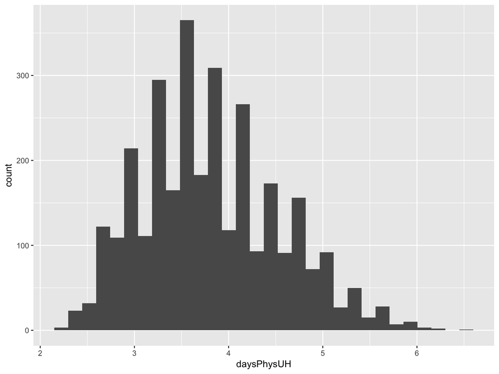

```r
#histogram for physically unhealthy days per month
hist_phys <- county %>%
  ggplot(aes(x=daysPhysUH)) +
  geom_histogram()

hist_phys
```

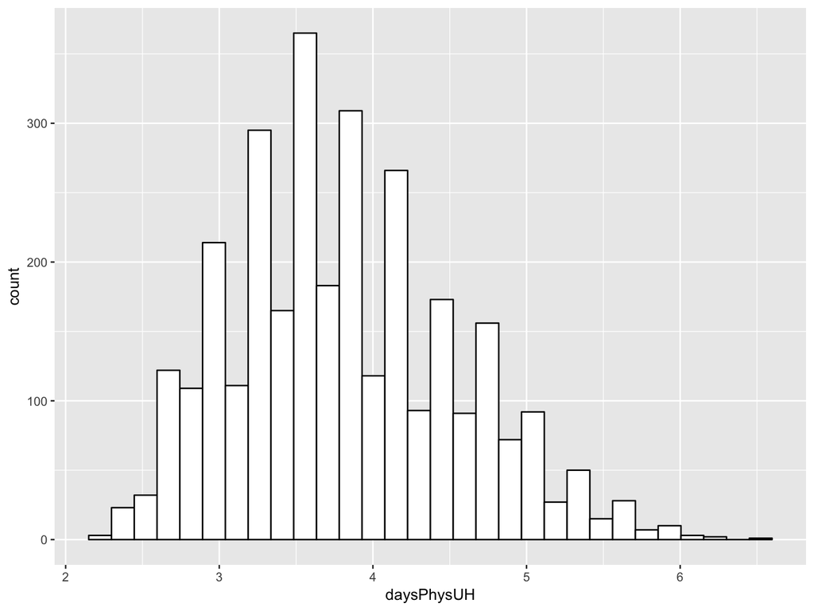

```r
#change bin colors
hist_phys <- county %>%
  ggplot(aes(x=daysPhysUH)) +
  geom_histogram(color="black", fill="white")

hist_phys
```

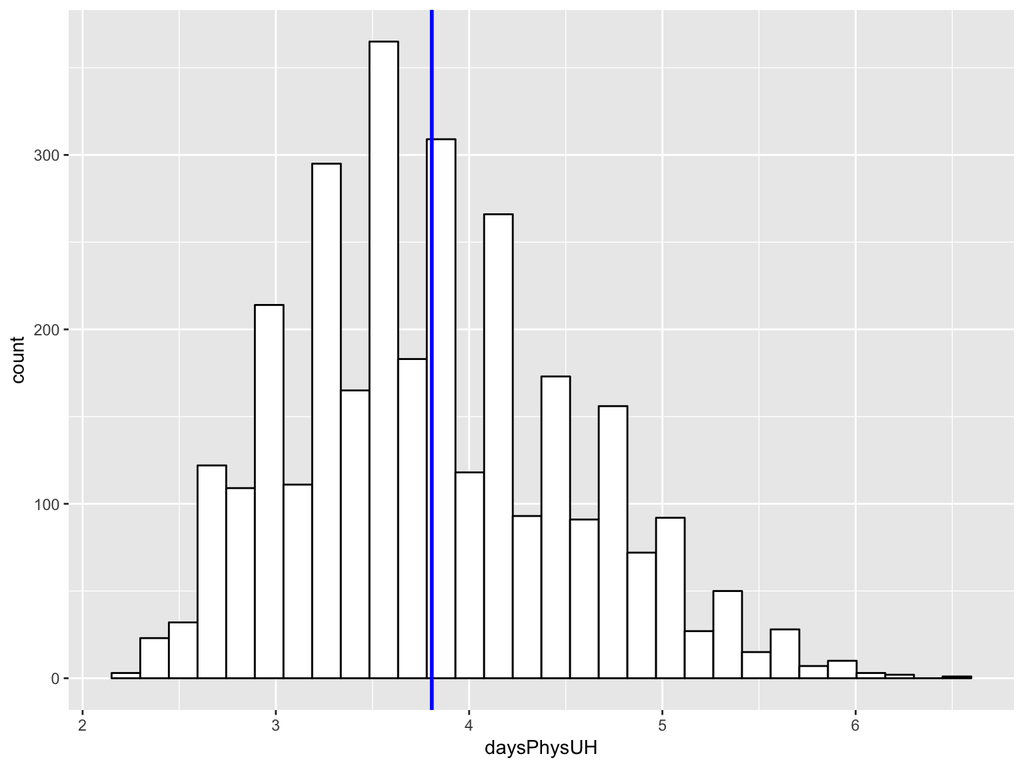

```r
#add a line where the mean is
hist_phys <- hist_phys +
  geom_vline(aes(xintercept = mean(daysPhysUH, na.rm=T)),
                    color="blue", size=1)
hist_phys
```

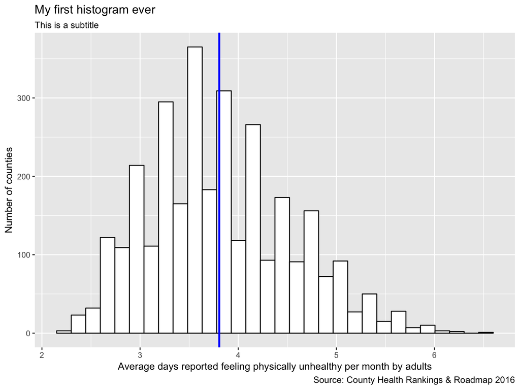

```r
#change the titles
hist_phys <- hist_phys +
  labs(x="Average days reported feeling physically unhealthy per month by adults",
       y= "Number of counties",
       title="My first histogram ever",
       subtitle="This is a subtitle",
       caption="Source: County Health Rankings & Roadmap 2016")

hist_phys
```

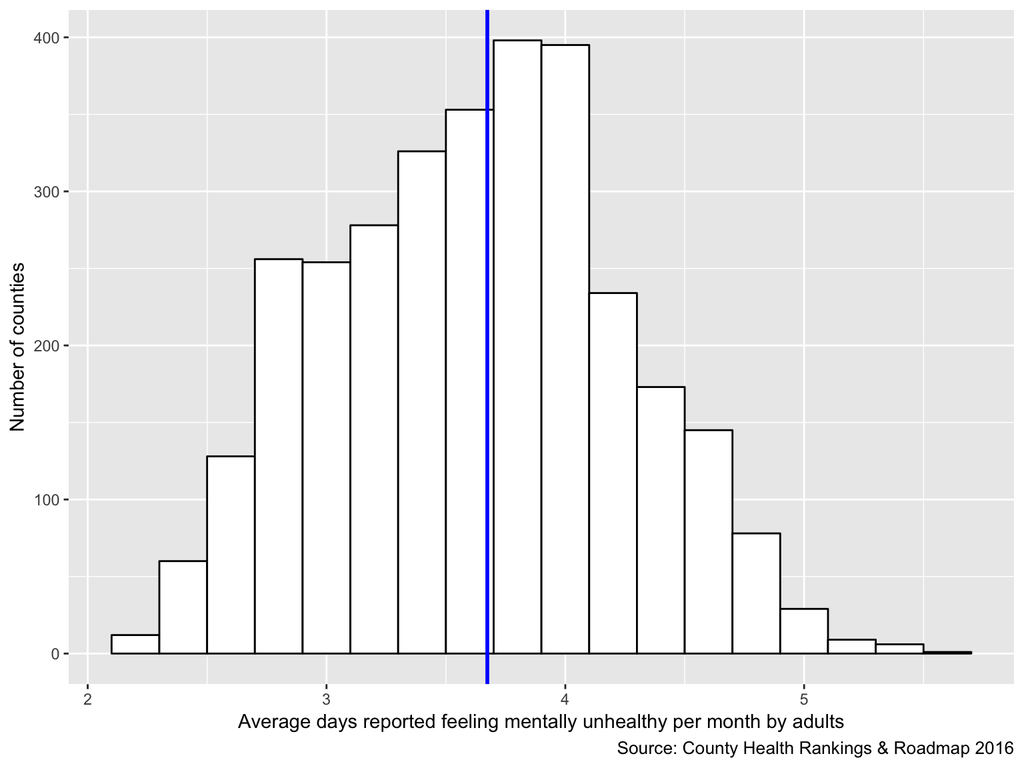

```r
#same histogram for mentally unhealthy days per month
hist_ment <- county %>%
  ggplot(aes(x=daysMentUH)) +
  geom_histogram(color="black", fill="white", binwidth=0.2) +
  geom_vline(aes(xintercept = mean(daysMentUH, na.rm=T)), color="blue", size=1) +
  labs(x="Average days reported feeling mentally unhealthy per month by adults",
       y= "Number of counties",
       caption="Source: County Health Rankings & Roadmap 2016")

hist_ment
```

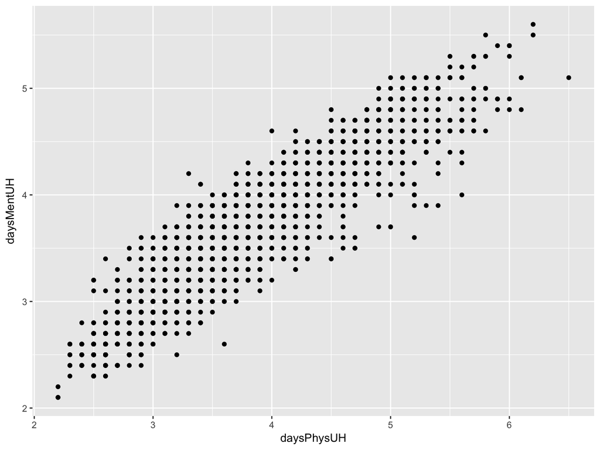

```r
#scatterplot for physically unhealthy days per month and mentally unhealthy days per month
scat <- county %>%
  ggplot(aes(x=daysPhysUH, y=daysMentUH)) +
  geom_point() #geom_point is used to create scatterplots

scat
```

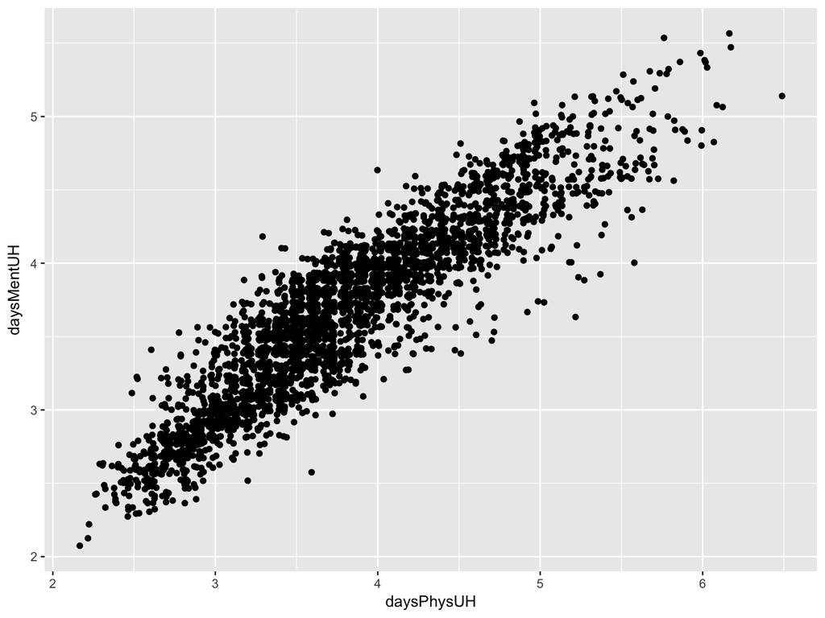

```r
#The jitter geom is a convenient shortcut for geom_point(position = "jitter").
#It adds a small amount of random variation to the location of each point
#a useful way of handling overplotting caused by discreteness in smaller datasets.

scat <- county %>%
  ggplot(aes(x=daysPhysUH, y=daysMentUH)) +
  geom_jitter()

scat
```

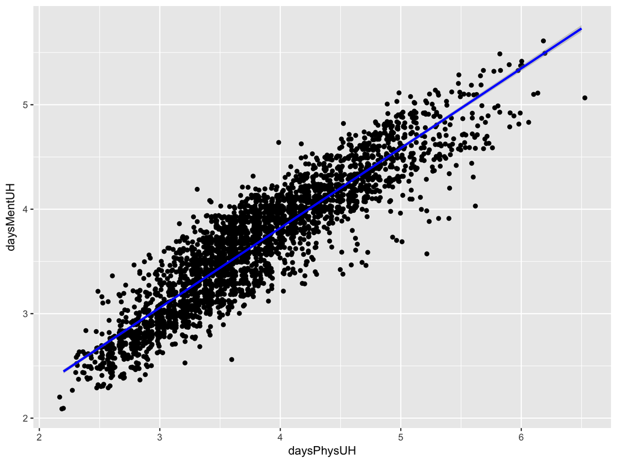

```r
#add a regression line
scat <- scat +
  geom_smooth(color="blue", method="lm")

scat
```

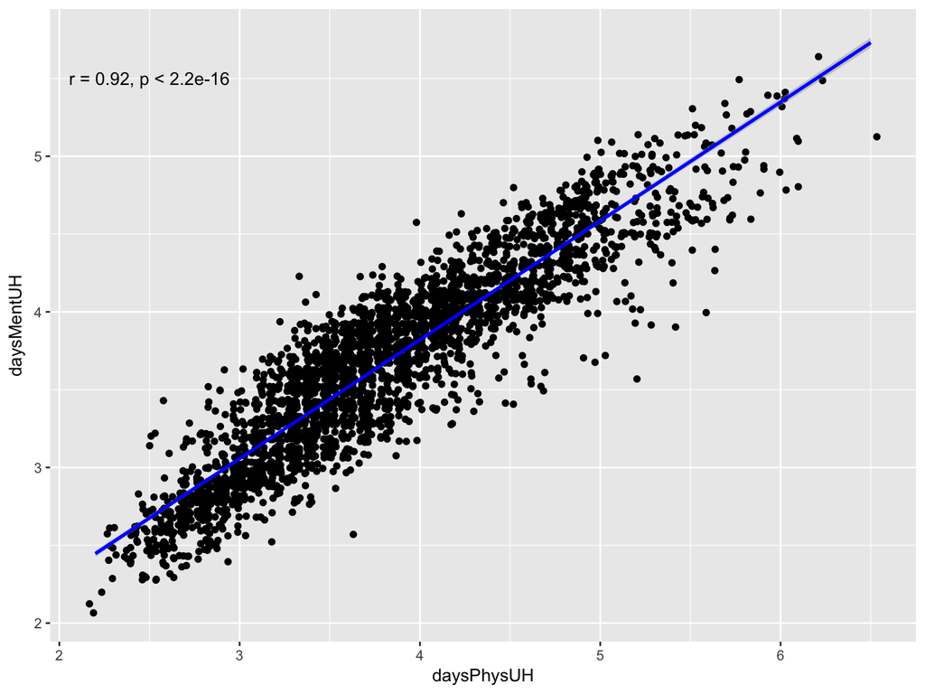

```r
# add correlation coefficient and p value
scat <- scat +
   stat_cor(method = "pearson", label.x = 2.5, label.y = 5.5)

scat
```

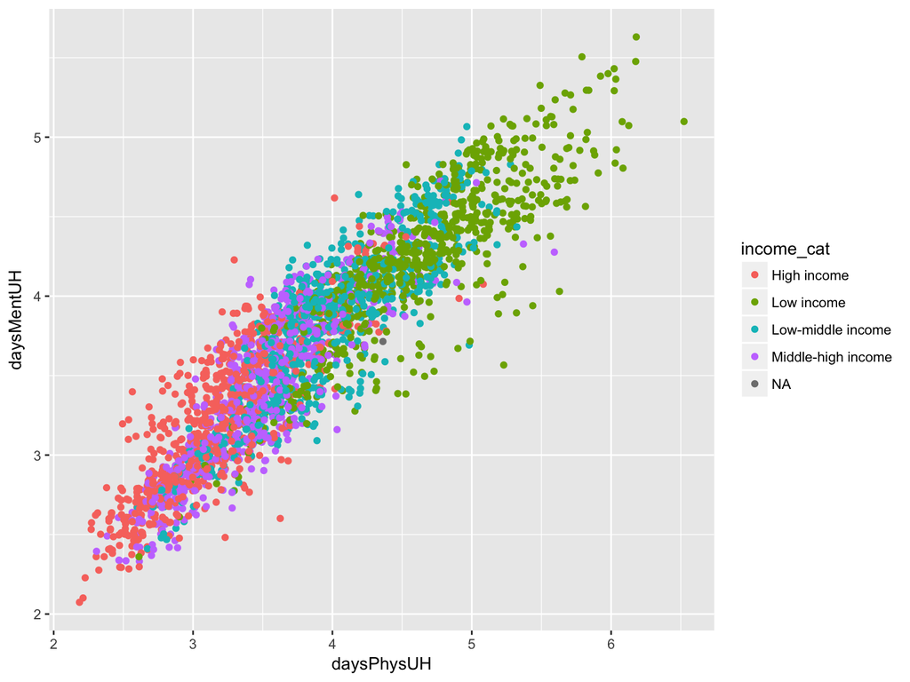

```r
#color the points by their income categories
scat_col <- county %>%
  ggplot(aes(x=daysPhysUH, y=daysMentUH, color=income_cat)) +
  geom_jitter()

scat_col
```

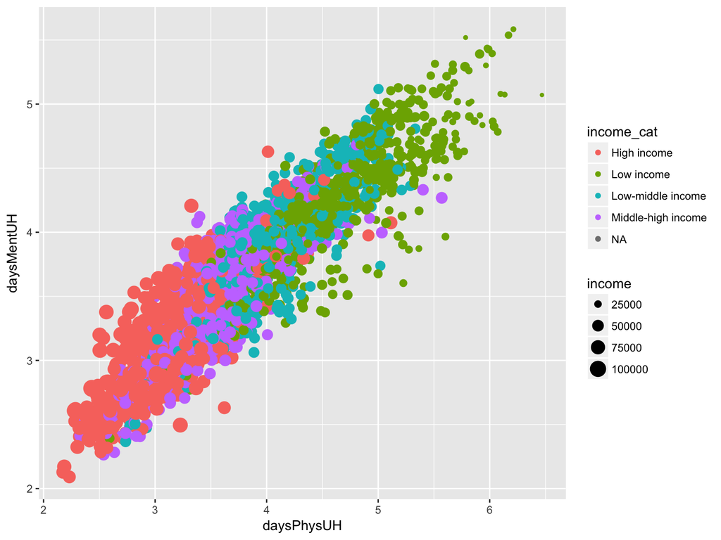

```r
#change the point size according to the income
scat_col <- county %>%
  ggplot(aes(x=daysPhysUH, y=daysMentUH, color=income_cat, size=income)) +
  geom_jitter()

scat_col
```

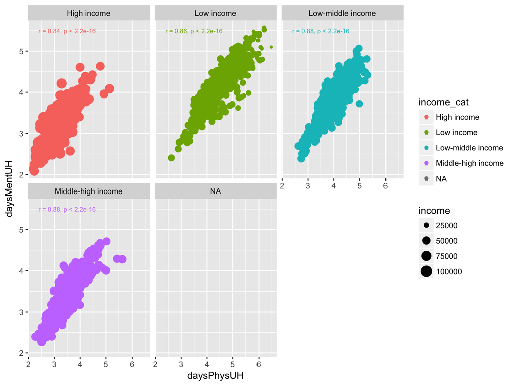

```r
#look at scatterplots by income categories
#add correlation coefficient and p value for each scatterplot

scat_col <- scat_col +
  facet_wrap(~income_cat) +
  stat_cor(method = "pearson", label.x = 3.5, label.y = 5.5, size=2.5)

scat_col
```

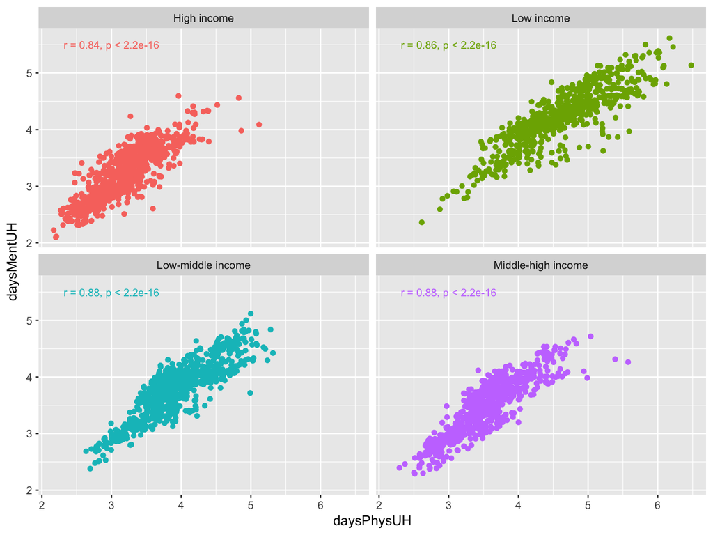

```r
#Drop cases with missing values on income
scat_col <- county %>%
  drop_na(income_cat) %>% #Drop all cases with missing values
  ggplot(aes(x=daysPhysUH, y=daysMentUH, color=income_cat)) +
  geom_jitter()+
  facet_wrap(~income_cat)+
  stat_cor(method = "pearson", label.x = 3, label.y = 5.5, size=3)+
  theme(legend.position = "none") #get rid of the redundant legend

scat_col
```

## Supplemental resources for R

- [R for Data Science](https://r4ds.had.co.nz/)
- [R IN ACTION: Data analysis and graphics with R](https://www.manning.com/books/r-in-action-second-edition)
- [Data Visualization: A practical introduction](http://socviz.co/index.html#preface)
- [Data Science Live Book](https://livebook.datascienceheroes.com/index.html#why-this-book)
- [dplyr](https://cran.r-project.org/web/packages/dplyr/vignettes/dplyr.html)
- [Exploratory data analysis in R](https://www.r-bloggers.com/exploratory-data-analysis-in-r-introduction/amp/?__twitter_impression=true)
- ggplot2
  - http://t-redactyl.io/blog/2016/01/creating-plots-in-r-using-ggplot2-part-4-stacked-bar-plots.html
  - https://www.r-bloggers.com/bar-plot-of-group-means-with-individual-observations/
  - https://www.r-bloggers.com/plotting-background-data-for-groups-with-ggplot2/
  - https://www.r-bloggers.com/plotting-likert-scales/
  - https://www.r-bloggers.com/make-a-bar-plot-with-ggplot/
  - http://t-redactyl.io/blog/2016/01/creating-plots-in-r-using-ggplot2-part-3-bar-plots.html
- [Hints for the R beginner](http://www.portfolioprobe.com/user-area/some-hints-for-the-r-beginner/)
- [HTML text & other formatting for R Notebooks](https://www.w3schools.com/html/html_formatting.asp)
- [Introduction to R from the R Core Team](https://cran.r-project.org/doc/manuals/R-intro.pdf)
- [Introduction to RStudio by Oscar Torres-Renya](http://dss.princeton.edu/training/RStudio101.pdf)
- [Learn R from Scratch - video tutorials](http://datascienceplus.com/learn-r-from-scratch-part-1/)
- [Learning R in seven simple steps](http://www.datasciencecentral.com/profiles/blogs/learning-r-in-seven-simple-steps)
- [List of free e-books for R](https://r-dir.com/learn/e-books.html)
- [List of R resources from StatsExchange](http://stats.stackexchange.com/questions/138/free-resources-for-learning-r)
- [Quick R](http://www.statmethods.net/)
- [R for Dummies](http://www.ievbras.ru/ecostat/Kiril/R/Biblio/R_eng/R%20dummies.pdf)
- [UCLA extensive list of R help topics](http://www.ats.ucla.edu/stat/r/)